# All Homework

19037

2020/01/03

## Overview

This rmarkdown is a summary of homework.

# 1

## Question

The allbacks data frame gives measurements on the volume and weight of 15 books, some of which are softback (pb) and some of which are hardback (hb). Use knitr to produce at least 3 examples(xtables,figures,texts).

### answer

First,as following,the allbacks data will be represented in the table directly.

```r
library(DAAG)
library(xtable)
data(allbacks)
print(xtable(allbacks[1:15, ]),type='html')
```

|  | volume | area | weight | cover |
| --- | --- | --- | --- | --- |
| 1 | 885.00 | 382.00 | 800.00 | hb |
| 2 | 1016.00 | 468.00 | 950.00 | hb |
| 3 | 1125.00 | 387.00 | 1050.00 | hb |
| 4 | 239.00 | 371.00 | 350.00 | hb |
| 5 | 701.00 | 371.00 | 750.00 | hb |
| 6 | 641.00 | 367.00 | 600.00 | hb |
| 7 | 1228.00 | 396.00 | 1075.00 | hb |
| 8 | 412.00 | 0.00 | 250.00 | pb |
| 9 | 953.00 | 0.00 | 700.00 | pb |
| 10 | 929.00 | 0.00 | 650.00 | pb |
| 11 | 1492.00 | 0.00 | 975.00 | pb |
| 12 | 419.00 | 0.00 | 350.00 | pb |
| 13 | 1010.00 | 0.00 | 950.00 | pb |
| 14 | 595.00 | 0.00 | 425.00 | pb |
| 15 | 1034.00 | 0.00 | 725.00 | pb |

Table which is presented above gives measurements on the volume and weight of 15 books, some of which are softback (pb) and some of which are hardback (hb).We can enter these columns of data,then plot volume against weight to give Figure,thus:

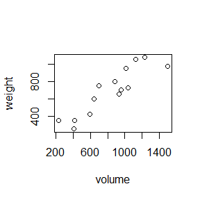

```r
attach(allbacks)
plot(volume,weight)
```

```r
detach(allbacks)
```

# 2

## Exercise 3.4

The Rayleigh density [156, Ch. 18] is $f(x)=x/(\sigma^2)*exp(-x^2/(2*\sigma^2)),x\geq 0,\sigma> 0$ Develop an algorithm to generate random samples from a Rayleigh($\sigma$) distribution. Generate Rayleigh($\sigma$) samples for several choices of $\sigma>0$ and check that the mode of the generated samples is close to the theoretical mode $\sigma$ (check the histogram).

### answer

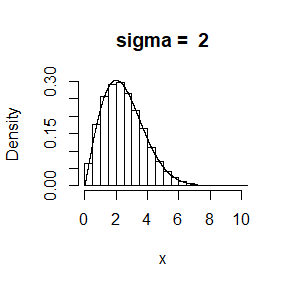

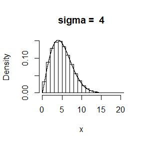

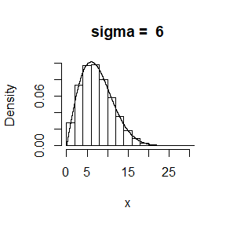

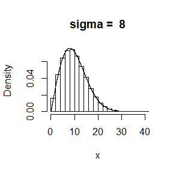

```r
n <- 100000
u <- runif(n)
m <- c(2,4,6,8)
#par(mfrow=c(2,2))
for(sigma in m){
x <- sqrt(-2*(sigma^2)*log(1-u))
#density histogram of sample
hist(x, prob = TRUE, main = paste("sigma = ",sigma))
y <- seq(0, 60, .001)
#density curve f(x)
lines(y, y/(sigma^2)*exp(-(y^2)/(2*sigma^2)))
}
```

The histogram and density plot in figure that we polted suggests that the empirical and theoretical distributions approximately agree.

## Exercise 3.11

Generate a random sample of size 1000 from a normal location mixture. The components of the mixture have $N(0,1)$ and $N(3,1)$ distributions with mixing probabilities $p_{1}$ and $p_{2}=1-p_{1}$. Graph the histogram of the sample with density superimposed, for $p_{1}=0.75$. Repeat with different values for $p_{1}$ and observe whether the empirical distribution of the mixture appears to be bimodal. Make a conjecture about the values of $p_{1}$ that produce bimodal mixtures.

### answer

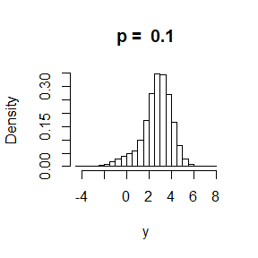

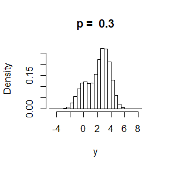

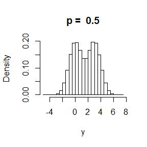

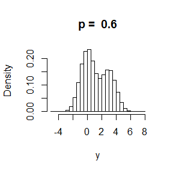

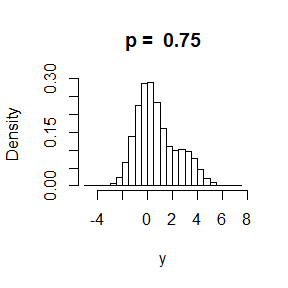

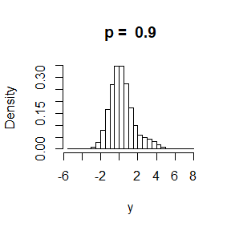

```r
n <- 1e6
l <- c(0.1,0.3,0.5,0.6,0.75,0.9)
#par(mfrow=c(2,3))
 for(p in l){
  x <- sample(c(0,1), size = n, replace = TRUE, prob = c(p, 1-p))
  y <- vector(length=n)
  for(i in 1:n){
    if(x[i] == 0)
    y[i] <- rnorm(1, mean = 0, sd = 1)
    else y[i] <- rnorm(1, mean = 3, sd = 1)
  }
 hist(y, prob = TRUE, main = paste("p = ", p))
}
```

## Exercise 3.18

Write a function to generate a random sample from a $wd(\sum ,n)$ (Wishart) distribution for $n>d+1\geq1$, based on Bartlett’s decomposition.

### answer

Choosing a matrix X based on Bartlett’s decomposition,. $X^{T}*X$ is a $wd(\sum ,n)$ (Wishart) distribution.

```r
library(MASS)
n <- 10
d <-5
m <- matrix(1:d^2, d, d)
sigma <- cov(m)
X <- mvrnorm(d, mu=1:d, sigma)
Y <- t(X)
Z <- Y%*%X
Z
```

```
##          [,1]     [,2]      [,3]      [,4]      [,5]
## [1,] 22.96551 33.36433  43.76316  54.16199  64.56081
## [2,] 33.36433 48.76316  64.16199  79.56081  94.95964
## [3,] 43.76316 64.16199  84.56081 104.95964 125.35847
## [4,] 54.16199 79.56081 104.95964 130.35847 155.75730
## [5,] 64.56081 94.95964 125.35847 155.75730 186.15612
```

The matrix Z (produced by matrix X and Y) is the matrix which is required.

# 3

## Exercise 5.1

Compute a Monte Carlo estimate of $\int_{0}^{\pi /3}sintdt$ and compare your estimate with the exact value of the integral.

### answer

```r
library(scales)
m <- 10000
x <- runif(m, min = 0, max = pi/3)
theta.hat <- mean(sin(x))*(pi/3)
print(theta.hat)
```

```
## [1] 0.500765
```

```r
print(-cos(pi/3)+1)
```

```
## [1] 0.5
```

a Monte Carlo estimate of $\int_{0}^{\pi /3}sintdt$ is 0.500765 and the estimate of the exact value of the integral is 0.5. Obviously, the Monte Carlo estimate value is approximate to the exact value.

## Exercise 5.10

Use Monte Carlo integration with antithetic variables to estimate $\int_{0}^{1}\frac{e^{-x}}{1+x^2}dx$, and find the approximate reduction in variance as a percentage of the variance without variance reduction.

### answer

```r
library(scales)
m <- 10000
U <- runif(m)
#simple MC
T1 <- exp(-U)/(1+U^2)
#MC with antithetic variables
U1 <- runif(m/2)
U2 <- 1-U1
T2 <- (exp(-U1)/(1+U1^2)+exp(-U2)/(1+U2^2))/2
#print the variance of T1 and T2
mean(T1)
```

```
## [1] 0.5287219
```

```r
mean(T2)
```

```
## [1] 0.5251758
```

```r
var(T1)
```

```
## [1] 0.06070935
```

```r
var(T2)
```

```
## [1] 0.001100937
```

```r
(var(T1)-var(T2))/var(T1)
```

```
## [1] 0.9818655
```

The approximate reduction in variance as a percentage 98%of the variance without variance reduction.

## Exercise 5.15

Obtain the stratified importance sampling estimate in Example 5.13 and compare it with the result of Example 5.10.

### answer

In Example5.10, our best result was obtained with importance function $f_3(x)=\frac{e^{-x}}{1-e^{-1}}, 0<x<1$. From 10000 replicates we obtained the estimate $\tilde{\theta }=0.5257801$ and an estimated standard error 0.0970314. Now divide the interval (0,1) into five subintervals, $(\frac{j}{5},\frac{j+1}{5}), j=0,1,\cdots ,4$. Then on the $j^{th}$ subinterval variables are generated from the density $\frac{5*e^{-x}}{1-e^{-1}}, \frac{j-1}{5}<x<\frac{j}{5}$

```r
M <- 1e5
k <- 5
N <- 50
T2 <- numeric(k)
est <- matrix(0, N, 2)
g <- function(x){
  (1-exp(-1))/(1+x^2)
}
for (i in 1:N) {
#importance sampling estimate
  u<-runif(M)
  x<--log(1-(1-exp(-1))*u)
  est[i, 1] <- mean(g(x))
  for(j in 1:k){
#stratified importance sampling estimate
    F1<-(1-exp((1-j)/5))/(1-exp(-1))
    F2<-(1-exp(-j/5))/(1-exp(-1))
    u<- runif((F2-F1)*M)
    x<- -log(1-(1-exp(-1))*((F2-F1)*u+F1))
    T2[j]<-mean((F2-F1)*g(x))
  }
  est[i, 2] <- sum(T2)
}
#print the outcoming
apply(est,2,mean)
```

```
## [1] 0.5247905 0.5247881
```

```r
apply(est,2,var)
```

```
## [1] 8.447469e-08 2.610416e-09
```

```r
apply(est,2,sd)
```

```
## [1] 2.906453e-04 5.109223e-05
```

conclusion:  
1. The mean of importance sampling estimate and stratified importance sampling estimate is 0.5247905, 0.5247881.  
2. The variance of importance sampling estimate and stratified importance sampling estimate is 8.447469110^{-8}, 2.61041610^{-9}.  
3. The standard error of importance sampling estimate and stratified importance sampling estimate is 2.90645310^{-4}, 5.109223110^{-5}.  
4. It is easy to find that the variance of importance sampling estimate is bigger than stratified importance sampling estimate’s. Obviously, the stratified importance sampling estimate’s variance is reduced more, this method is a better choice.

# 4

## Exercise 6.5

Suppose a 95% symmetric t-interval is applied to estimate a mean, but the sample data are non-normal. Then the probability that the confidence interval covers the mean is not necessarily equal to 0.95. Use a Monte Carlo experiment to estimate the coverage probability of the t-interval for random samples of $\chi^{2}(2)$ data with sample size n = 20. Compare your t-interval results with the simulation results in Example 6.4. (The t-interval should be more robust to departures from normality than the interval for variance.)

### answer

Example 6.4  
If $X_1,\cdots, X_n$ is a random sample from a Normal $(u,\sigma^2)$ distribution, $n\geqslant 2$, and $S^2$ is the sample variance, then $V = \frac{(n-1)S^2}{\sigma^2}\sim \chi^2(n-1)$  
A one side $100(1-\alpha)%$ confidence interval is given by $(0,\frac{(n-1)S^2}{\chi^2_\alpha})$, where $\chi^2_\alpha$ is the $\alpha$-quantile of the $\chi^2(n-1)$ distribution. If the sampled population is normal with variance $\sigma^2$, then the probability that the confidence interval contains $\sigma^2$ is $1-\alpha$.

```r
#x is from a normal distribution
library(scales)
n <- 20
alpha <- 0.05
UCL1 <- replicate(1000, expr={
  x <- rnorm(n, mean=0, sd=2)
  (n-1)*var(x) / qchisq(alpha, df=n-1)
})
sum(UCL1 > 4)
```

```
## [1] 948
```

```r
mean(UCL1 > 4)
```

```
## [1] 0.948
```

The result is that 948 intervals satisfied (UCL1 > 4), so the empirical confidence level is 95% in this experiment. The result will vary but should be close to the theoretical value, 95%.

```r
#x is from a chi-square data.
n <- 20
alpha <- 0.05
UCL2 <- replicate(1000, expr = {
  x <- rchisq(n, df = 2)
  (n-1) * var(x) / qchisq(alpha, df = n-1)
})
sum(UCL2 > 4)
```

```
## [1] 781
```

```r
mean(UCL2 > 4)
```

```
## [1] 0.781
```

The result is that 781 intervals satisfied (UCL2 > 4), so the empirical confidence level is 78% in this experiment. The result will vary but should be close to the theoretical value, 78%.

In exercise 6.5

```r
n <- 20
alpha <- 0.05
U1 <- replicate(1000, expr={
  x <- rchisq(n, df = 2)
  mean(x) - sqrt(var(x)/n)* qt(alpha/2, df = n-1)
})
U2 <- replicate(1000, expr={
  x <- rchisq(n, df = 2)
  mean(x) + sqrt(var(x)/n)* qt(alpha/2, df = n-1)
})
mean(U1 > 2 & U2 < 2)
```

```
## [1] 0.925
```

The coverage probability of the t-interval for random samples of $\chi^{2}(2)$ data with sample size n = 20 is 92%, it is very approximate to 95%.

discuss: if x is from normal distribution, how about the coverage probablity?

```r
n <- 20
alpha <- 0.05
U3 <- replicate(1000, expr={
  x <- rnorm(n, mean = 0, sd = 2 )
  mean(x) - sqrt(var(x)/n)* qt(alpha/2, df = n-1)
})
U4 <- replicate(1000, expr={
  x <- rnorm(n, mean = 0, sd = 2 )
  mean(x) + sqrt(var(x)/n)* qt(alpha/2, df = n-1)
})
mean(U3 > 0 & U4 < 0)
```

```
## [1] 0.943
```

The coverage probability is 94%, the result is very well.

## Exercise 6.6

Estimate the 0.025, 0.05, 0.95, and 0.975 quantiles of the skewness $\sqrt{b_1}$ under normality by a Monte Carlo experiment. Compute the standard error of the estimates from (2.14) using the normal approximation for the density (with exact variance formula). Compare the estimated quantiles with the quantiles of the large sample approximation $\sqrt{b_1}\approx N(0,6/n)$

### answer

2.14 $Var(\hat{x_q})=\frac{q(1-q)}{nf(x_q)^2}$

```r
#Estimate the quantiles of the skewness under normality by a Monte Carlo experiment
n <- 1000
m <- 10000
sk <- numeric(n)
for (i in 1:m){
  x <- rnorm(n)
  xbar <- mean(x)
  m3 <- mean((x - xbar)^3)
  m2 <- mean((x - xbar)^2)
  sk[i] <- m3 / m2^1.5
}
y1 <- unname(quantile(sk,c(0.025, 0.05, 0.95, 0.975)))
y1
```

```
## [1] -0.1499644 -0.1256417  0.1283651  0.1533147
```

The quantiles of the skewness under normality by a Monte Carlo experiment is -0.1499644, -0.1256417, 0.1283651, 0.1533147

```r
#Compute the standard error of the estimates from (2.14) using the normal approximation for the density (with exact variance formula)
n <- 1000
q <- c(0.025, 0.05, 0.95, 0.975)
f <- qnorm(q, mean = 0, sd = sqrt(6*(n-2)/((n+1)*(n+3))))
sd <- sqrt(q*(1-q)/(n*f^2))
sd
```

```
## [1] 0.03261751 0.05425580 0.05425580 0.03261751
```

The standard error of the estimates from (2.14) using the normal approximation for the density (with exact variance formula) is 0.0326175, 0.0542558, 0.0542558, 0.0326175

```r
#estimated quantiles with the quantiles of the large sample approximation N(0,6/n)
n <- 1000
y2 <- qnorm(c(0.025, 0.05, 0.95, 0.975), mean = 0, sd = sqrt(6/n))
y2
```

```
## [1] -0.1518182 -0.1274098  0.1274098  0.1518182
```

The quantiles with the quantiles of the large sample approximation N(0,6/n) is -0.1518182, -0.1274098, 0.1274098, 0.1518182

```r
#compare the quantiles
data.frame(quantiles = c(0.025, 0.05, 0.95, 0.975), q_MC_est = y1, q_sample_approximation = y2, sd)
```

```
##   quantiles   q_MC_est q_sample_approximation         sd
## 1     0.025 -0.1499644             -0.1518182 0.03261751
## 2     0.050 -0.1256417             -0.1274098 0.05425580
## 3     0.950  0.1283651              0.1274098 0.05425580
## 4     0.975  0.1533147              0.1518182 0.03261751
```

From the table, we can find the estimated quantiles with the quantiles of the large sample approximation $\sqrt{b_1}\approx N(0,6/n)$ are almost same.

# 5

## Exercise 6.7

Estimate the power of the skewness test of normality against symmetric $Beta(\alpha,\alpha)$ distributions and comment on the results. Are the results different for heavy-tailed symmetric alternatives such as $t(v)$?

### answer

symmetric Beta distribution

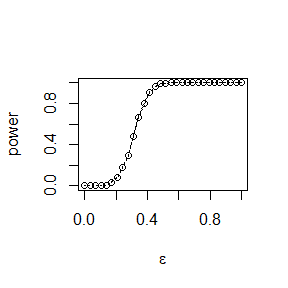

```r
alpha <- 1
n <- 100
m <- 2500
epsilon <-seq(0, 1, length.out = 30)
N <- length(epsilon)
power <- numeric(N)

#computes the sample skewness coeff.
sk <- function(x) {
  xbar <- mean(x)
  m3 <- mean((x - xbar)^3)
  m2 <- mean((x - xbar)^2)
  return( m3 / m2^1.5 )
  }

#critical value for the skewness test
cv <- qnorm(0.975, 0, sqrt(6*(n-2) / ((n+1)*(n+3))))

for (j in 1:N) {
  #for each epsilon
  e <- epsilon[j]
  sktests <- numeric(m)
  for (i in 1:m) {
    #for each replicate
    Y <- sample(0:1, size = n, replace = TRUE,prob = c(1-e, e))
    x <- rbeta(n, alpha, alpha) * (Y == 0) + rbeta(n, alpha, 100*alpha) * (Y == 1)
    sktests[i] <- (abs(sk(x)) >= cv)
  }
  power[j] <- mean(sktests)
}

#plot power vs epsilon
plot(epsilon, power, type = "b", xlab = bquote(epsilon), ylim = c(0,1))
#abline(h = .1, lty = 3)
se <- sqrt(power * (1-power) / m)
#add standard errors
lines(epsilon, power+se, lty = 3)
lines(epsilon, power-se, lty = 3)
```

By considering the figure, the power is increasing when epsilon is increasing, and when epsilon approximately equals to 0.5, power is already approximately equals to 1.

heavy-tailed symmetric alternatives such as t(v)

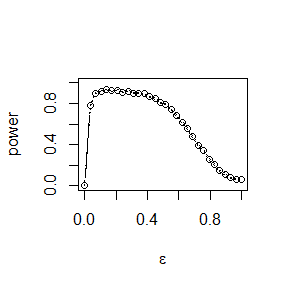

```r
alpha <- 3
n <- 100
m <- 2500
epsilon <-seq(0, 1 ,length.out = 30)
N <- length(epsilon)
power <- numeric(N)

#computes the sample skewness coeff.
sk <- function(x) {
  xbar <- mean(x)
  m3 <- mean((x - xbar)^3)
  m2 <- mean((x - xbar)^2)
  return( m3 / m2^1.5 )
}

#critical value for the skewness test
cv <- qnorm(0.975, 0, sqrt(6*(n-2) / ((n+1)*(n+3))))

for (j in 1:N) {
  #for each epsilon
  e <- epsilon[j]
  sktests <- numeric(m)
  for (i in 1:m) {
    #for each replicate
    Y <- sample(0:1, size = n, replace = TRUE, prob = c(1-e, e))
    x <- rbeta(n, alpha, alpha) * (Y == 0) + rt(n, 100*alpha) * (Y == 1)
    sktests[i] <- (abs(sk(x)) >= cv)
  }
  power[j] <- mean(sktests)
}

#plot power vs epsilon
plot(epsilon, power, type = "b", xlab = bquote(epsilon), ylim = c(0,1))
#abline(h = .1, lty = 3)
se <- sqrt(power * (1-power) / m)
#add standard errors
lines(epsilon, power+se, lty = 3)
lines(epsilon, power-se, lty = 3)
```

conclusion：After estimating the power of the skewness test of normality against symmetric $Beta(\alpha,\alpha)$ distributions, it comes to a conclusion that the results different for heavy-tailed symmetric alternatives such as $t(v)$.

## Exercise 6.A

Use Monte Carlo simulation to investigate whether the empirical Type I error rate of the t-test is approximately equal to the nominal significance level $\alpha$, when the sampled population is non-normal. The t-test is robust to mild departures from normality. Discuss the simulation results for the cases where the sampled population is  
(i) $\chi ^{2}(1)$  
(ii) Uniform(0,2)  
(iii) Exponential(rate=1) In each case, test $H_{0} : \mu=\mu_{0}$ vs $H_{0} : \mu\neq\mu_{0}$, where $\mu_{0}$ is the mean of $\chi^{2}(1)$, Uniform(0,2), and Exponential(1), respectively.

### answer

Case(i): chisq(1)

```r
n <- 20
alpha <- .05
mu0 <- 1 #null hypothesis
m <- 10000 #number of replicates
p <- numeric(m) #storage for p-values
for (j in 1:m) {
  x <- rchisq(n, mu0)
  ttest <- t.test(x, mu = mu0)
  p[j] <- ttest$p.value
  }
p.hat <- mean(p < alpha)
p.hat
```

```
## [1] 0.1083
```

By the Monte Carlo simulation, the empirical Type I error rate of the t-test for the cases where the sampled population is $\chi^{2}(1)$, is much bigger than the nominal significance level $\alpha$.

Case(ii): Uniform(0,2)

```r
n <- 20
alpha <- 0.05
mu0 <- 1 #null hypothesis
m <- 10000 #number of replicates
p <- numeric(m) #storage for p-values
for (j in 1:m) {
  x <- runif(n, min = 0, max = 2)
  ttest <- t.test(x, mu = mu0)
  p[j] <- ttest$p.value
  }
p.hat <- mean(p < alpha)
p.hat
```

```
## [1] 0.053
```

By the Monte Carlo simulation, the empirical Type I error rate of the t-test for the cases where the sampled population is Uniform(0,2), is approximately equal to the nominal significance level $\alpha$.

Case(iii): Exponential(rate=1)

```r
n <- 20
alpha <- .05
mu0 <- 1  #null hypothesis
m <- 10000 #number of replicates
p <- numeric(m) #storage for p-values
for (j in 1:m) {
  x <- rexp(n, rate = 1)
  ttest <- t.test(x, mu = mu0)
  p[j] <- ttest$p.value
  }
p.hat <- mean(p < alpha)
p.hat
```

```
## [1] 0.0792
```

By the Monte Carlo simulation, the empirical Type I error rate of the t-test for the cases where the sampled population is Exponential(rate=1), is little bigger than the nominal significance level $\alpha$.

## Exercise3: Discussion

If we obtain the powers for two methods under a particular simulation setting with 10,000 experiments: says, 0.651 for one method and 0.676 for another method. Can we say the powers are different at 0.05 level? 1. What is the corresponding hypothesis test problem? 2. What test should we use? Z-test, two-sample t-test, paired-t-test or McNemar test? 3. What information is needed to test your hypothesis?

### answer

1. Let $P_1$ denote the power for one method, and $P_2$ for another method.Let $T_1$ denote the testing statistic for one method, and $T_2$ for another method.Let $W_1$ denote the rejection area for one method, and $W_2$ for another method. The significant level is $\alpha=0.05$.Then the test hypotheses are $H0 : P1 = P2$ vs $H1 : P1 \neq P2$. If H0 is false, we can say the powers are different at 0.05 level, otherwise, we can’t say the powers are different at 0.05 level.
2. Firstly, these four methods will be introduced shortly:
- Z-test: A Z-test is any statistical test for which the distribution of the test statistic under the null hypothesis can be approximated by a normal distribution. Because of the central limit theorem, many test statistics are approximately normally distributed for large samples. For each significance level, the Z-test has a single critical value (for example, 1.96 for 5% two tailed) which makes it more convenient than the Student’s t-test which has separate critical values for each sample size. Therefore, many statistical tests can be conveniently performed as approximate Z-tests if the sample size is large or the population variance is known. If the population variance is unknown (and therefore has to be estimated from the sample itself) and the sample size is not large (n < 30), the Student’s t-test may be more appropriate.
- two sample t-test: In statistics, “two sample t-test” is also named “Welch’s t-test”, or “unequal variances t-test”, is a two-sample location test which is used to test the hypothesis that two populations have equal means. It is named for its creator, Bernard Lewis Welch, and is an adaptation of Student’s t-test, and is more reliable when the two samples have unequal variances and/or unequal sample sizes. These tests are often referred to as “unpaired” or “independent samples” t-tests, as they are typically applied when the statistical units underlying the two samples being compared are non-overlapping. Given that Welch’s t-test has been less popular than Student’s t-test and may be less familiar to readers, a more informative name is “Welch’s unequal variances t-test” — or “unequal variances t-test” for brevity.
- paired sample t-test: In statistic, paired sample t-test is used to compare two means that are repeated measures for the same participants - scores might be repeated across different measures or across time. It is also used also to compare paired samples, as in a two treatment randomized block design.
- MCNemar test: McNemar’s test is a statistical test used on paired nominal data. It is applied to 2 × 2 contingency tables with a dichotomous trait, with matched pairs of subjects, to determine whether the row and column marginal frequencies are equal (that is, whether there is “marginal homogeneity”). It is named after Quinn McNemar, who introduced it in 1947. An application of the test in genetics is the transmission disequilibrium test for detecting linkage disequilibrium. The commonly used parameters to assess a diagnostic test in medical sciences are sensitivity and specificity. Sensitivity is the ability of a test to correctly identify the people with disease. Specificity is the ability of the test to correctly identify those without the disease. Now presume two tests are performed on the same group of patients. And also presume that these tests have identical sensitivity and specificity. In this situation one is carried away by these findings and presume that both the tests are equivalent. However this may not be the case. For this we have to study the patients with disease and patients without disease (by a reference test). We also have to find out where these two tests disagree with each other. This is precisely the basis of McNemar’s test. This test compares the sensitivity and specificity of two diagnostic tests on the same group of patients.

After learning four methods, as for this problem, the best chance is “MCNemar test”. Because we have two samples and these two samples are not independent.

3. The information what we need is: the rejection area $W_1$, $W_2$, the testing statistic $T_1$, $T_2$.

# 6

## Exercise 7.6

Efronand Tibshirani discuss the scor (bootstrap) test score data on 88 students who took examinations in five subjects [84, Table 7.1], [188, Table 1.2.1]. The first two tests (mechanics, vectors) were closed book and the last three tests (algebra, analysis, statistics) were open book. Each row of the data frame is a set of scores $(x_{i1},\cdots,x_{i5})$ for the $i^{th}$ student. Use a panel display to display the scatter plots for each pair of test scores. Compare the plot with the sample correlation matrix. Obtain bootstrap estimates of the standard errors for each of the following estimates: $\hat{\rho }_{12}=\hat{\rho}(mec, vec)$, $\hat{\rho }_{34}=\hat{\rho}(alg,ana)$, $\hat{\rho }_{35}=\hat{\rho}(alg, sta)$, $\hat{\rho }_{45}=\hat{\rho}(ana, sta)$.

### answer

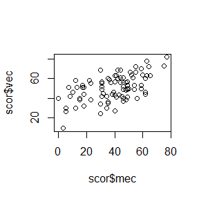

```r
library(bootstrap)
#par(mfrow = c(2, 2))
plot(scor$mec, scor$vec)
```

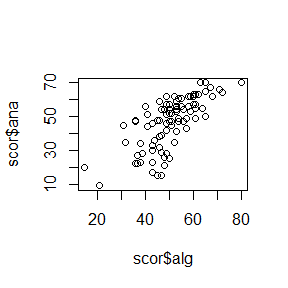

```r
plot(scor$alg, scor$ana)
```

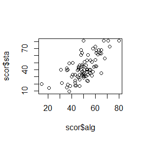

```r
plot(scor$alg, scor$sta)
```

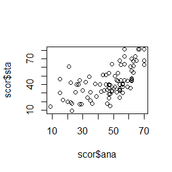

```r
plot(scor$ana, scor$sta)
```

```r
#get the sample correlation matrix
cor(scor)
```

```
##           mec       vec       alg       ana       sta
## mec 1.0000000 0.5534052 0.5467511 0.4093920 0.3890993
## vec 0.5534052 1.0000000 0.6096447 0.4850813 0.4364487
## alg 0.5467511 0.6096447 1.0000000 0.7108059 0.6647357
## ana 0.4093920 0.4850813 0.7108059 1.0000000 0.6071743
## sta 0.3890993 0.4364487 0.6647357 0.6071743 1.0000000
```

```r
#Obtain bootstrap estimates of the standard errors
#set up the bootstrap
B <- 200 #number of replicates
n <- nrow(scor) #sample size
R12 <- R34 <- R35 <- R45 <- numeric(B) #storage for replicates

#bootstrap estimate of standard error of R
for (b in 1:B) {
  #randomly select the indices
  i <- sample(1:n, size = n, replace = TRUE)
  mec <- scor$mec[i] #i is a vector of indices
  vec <- scor$vec[i]
  alg <- scor$alg[i]
  ana <- scor$ana[i]
  sta <- scor$sta[i]
  R12[b] <- cor(mec, vec)
  R34[b] <- cor(alg, ana)
  R35[b] <- cor(alg, sta)
  R45[b] <- cor(ana, sta)
}
# to compute standard error by using the bootstrap estimate.
se.R12 <- sd(R12)
se.R34 <- sd(R34)
se.R35 <- sd(R35)
se.R45 <- sd(R45)
# draw a table to present the result.
p <- matrix(c(se.R12, se.R34, se.R35, se.R45), 1)
colnames(p) <- c("Rho_12","Rho_34","Rho_35","Rho_45")
rownames(p) <- "Standard Errors"
knitr::kable(p)
```

|  | Rho_12 | Rho_34 | Rho_35 | Rho_45 |
| --- | --- | --- | --- | --- |
| Standard Errors | 0.0732255 | 0.0471147 | 0.0649671 | 0.0652751 |

## Project 7.B

Repeat Project 7.A for the sample skewness statistic. Compare the coverage rates for normal populations (skewness 0) and $\chi^2(5)$ distributions (positive skewness).

### answer

Project 7.A Conduct a Monte Carlo study to estimate the coverage probabilities of the standard normal bootstrap confidence interval, the basic bootstrap confidence interval, and the percentile confidence interval. Sample from a normal population and check the empirical coverage rates for the sample mean. Find the proportion of times that the confidence intervals miss on the left, and the porportion of times that the confidence intervals miss on the right.

```r
library(boot)
n <- 10
m <- 1e3
B <- 2000
ci.norm <- ci.basic <- ci.perc <- ci.bca <- matrix(0, m, 2)

#computes the sample skewness coeff.
sk <- function(x,i) {
  x<-x[i]
  xbar <- mean(x)
  m3 <- mean((x - xbar)^3)
  m2 <- mean((x - xbar)^2)
  return( m3 / m2^1.5 )
}
```

the normal populations (skewness 0) distributions

```r
sk.norm = 0
for(i in 1:m){
  U <- rnorm(n)
  de <- boot(data = U, statistic = sk, B)
  ci <- boot.ci(de, type = c("norm", "basic", "perc"))
  ci.norm[i,] <- ci$norm[2:3]
  ci.basic[i,] <- ci$basic[4:5]
  ci.perc[i,] <- ci$percent[4:5]
  }
cat('norm =', mean(ci.norm[,1] <= sk.norm & ci.norm[,2] >= sk.norm), 'basic =', mean(ci.basic[,1] <= sk.norm & ci.basic[,2] >= sk.norm), 'perc =', mean(ci.perc[,1] <= sk.norm & ci.perc[,2] >= sk.norm))
```

```
## norm = 0.904 basic = 0.891 perc = 0.999
```

The coverage rates for normal populations of the standard normal bootstrap confidence interval is 0.904;  
The coverage rates for normal populations of the basic bootstrap confidence interval is 0.891;  
The coverage rates for normal populations of the percentile confidence interval is 0.999.

the chisq distributions (positive skewness)

```r
sk.chisq = 4/sqrt(10)
for(i in 1:m){
  U <- rchisq(n, df = 5)
  de <- boot(data = U, statistic = sk, B)
  ci <- boot.ci(de, type = c("norm", "basic", "perc"))
  ci.norm[i,] <- ci$norm[2:3]
  ci.basic[i,] <- ci$basic[4:5]
  ci.perc[i,] <- ci$percent[4:5]
  }
cat('norm =', mean(ci.norm[,1] <= sk.chisq & ci.norm[,2] >= sk.chisq), 'basic =', mean(ci.basic[,1] <= sk.chisq & ci.basic[,2] >= sk.chisq), 'perc =', mean(ci.perc[,1] <= sk.chisq & ci.perc[,2] >= sk.chisq))
```

```
## norm = 0.754 basic = 0.725 perc = 0.739
```

The coverage rates for $\chi^2(5)$ distribution of the standard normal bootstrap confidence interval is 0.754;  
The coverage rates for $\chi^2(5)$ distribution of the basic bootstrap confidence interval is 0.725;  
The coverage rates for $\chi^2(5)$ distribution of the percentile confidence interval is 0.739.